# Reproducible Research - Course Project 1 - Week 2

Juan Sebastian Cuervo

8 de julio de 2018

The following Markdown shows my work for the Assigment of Reproducible Research Week 2. I show each of the steps and make the required comments if necessary either to answer the questions or clarify any particular procedure or step.

## Loading and preprocessing the data

1. Load the data

We load the data with the read,csv() function

```r
data <- read.csv("activity.csv", sep=",",header=TRUE)
```

2. Process/transform the data (if necessary) into a format suitable for your analysis

As the variable “date” class is interpreted as factor, we transform it in a Date Class for further usage.

```r
data$date <- as.Date(data$date,format="%Y-%m-%d")
```

## What is mean total number of steps taken per day?

1. Calculate the total number of steps taken per day

First we ignore the Missing Values as indicated by the instructions. With the aggregate command, we collapse data into a new set containing the sum of the steps for each particular date. The data computes the following:

```r
pasosdia <- aggregate(steps ~ date, data, sum)
```

2. Make a histogram of the total number of steps taken each day

The histogram builds classes or groups of data depending in the number of steps given per date. This approximates a probalistic distribution, different from a box plot that only plot specific values

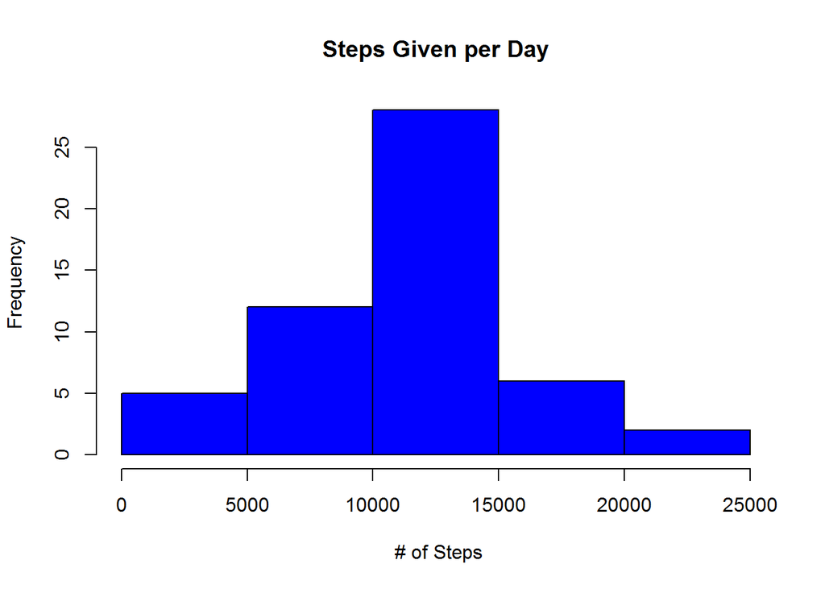

```r
hist(pasosdia$steps, main = paste("Steps Given per Day"), col="blue", xlab=" # of Steps")
```

```r
dev.copy(png, file="Gráfica1.png", width= 480, height=480)
```

```r
dev.off()
```

3. Calculate and report the mean and median of the total number of steps taken per day

We calculate the average number of steps given in any particular day with the aggregate() command. Then we estimate the average of the distribution of the histogram with the data called pasosdia. As shown in the histogram before, the mean of the histogram is acchived in the value 10766.19

```r
mediapas <-aggregate(steps ~ date, data, mean)
mediatotal <- mean(pasosdia$steps)
mediatotal ## Mean of total steps per day
```

```
## [1] 10766.19
```

We repeat the procedure for the median value. The median is 10765

```r
medianapordia <-aggregate(steps ~ date, data, FUN= median)
medianatotal <- median(pasosdia$steps)
medianatotal
```

```
## [1] 10765
```

## What is the average daily activity pattern?

1. Make a time series plot of the 5-minute interval (x-axis) and the average number of steps taken, averaged across all days (y-axis)

As before we use the aggregate function this time by interval variable. Then we plot the values.

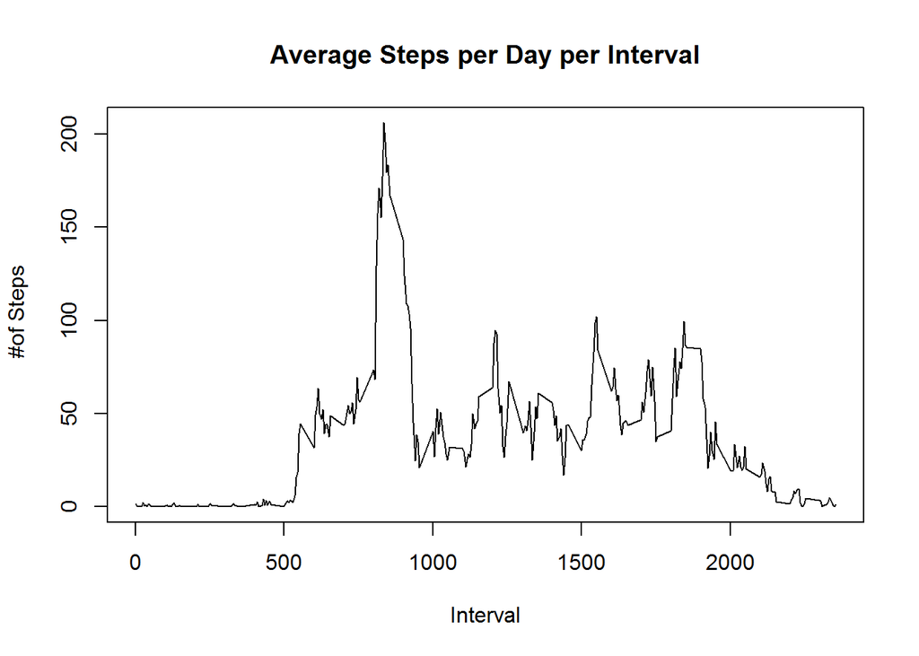

```r
pasosporintervalo <- aggregate(steps ~ interval, data, mean)
plot(pasosporintervalo$interval,pasosporintervalo$steps, type="l", xlab="Interval", ylab=" #of Steps",main="Average Steps per Day per Interval")
```

```r
dev.copy(png, file="Gráfica2.png", width= 480, height=480)
```

```r
dev.off()
```

2. Which 5-minute interval, on average across all the days in the dataset, contains the maximum number of steps?

```r
maximopintervalo <- pasosporintervalo[which.max(pasosporintervalo$steps),1]
maximopintervalo
```

```
## [1] 835
```

From the code we can see that the maximum number of steps is achieved at interval 835

## Imputing missing values

1. Calculate and report the total number of missing values in the dataset

We use the is.na() function and report the number of Missing Values ( 2304 values)

```r
numNas <- sum(is.na(data$steps))
numNas
```

```
## [1] 2304
```

2. Devise a strategy for filling in all of the missing values in the dataset.

3.Create a new dataset that is equal to the original dataset but with the missing data filled in.

```r
datanueva <- transform(data, steps = ifelse(is.na(data$steps), pasosporintervalo$steps[match(data$interval, pasosporintervalo$interval)], data$steps))
```

4. Make a histogram of the total number of steps taken each day and Calculate and report the mean and median total number of steps taken per day. Do these values differ from the estimates from the first part of the assignment? What is the impact of imputing missing data on the estimates of the total daily number of steps?

Following similar steps as before, we calculate the number of steps per day the means and the median

```r
pasosnueva <- aggregate(steps ~ date, datanueva, sum)
medianueva <- aggregate(steps ~ date,datanueva, mean)
mediatotalnueva <- mean(pasosnueva$steps)
mediananueva <-aggregate(steps ~ date, datanueva, median)
medianatotalnueva <- median(pasosnueva$steps)

mediatotalnueva
```

```
## [1] 10766.19
```

```r
medianatotalnueva
```

```
## [1] 10766.19
```

The new mean is 10766.19 and the median 10766.19. The new missing values don´t alter significantly the mean and the median of the results. In order to show it, we plot both histograms in the following code with the par() function

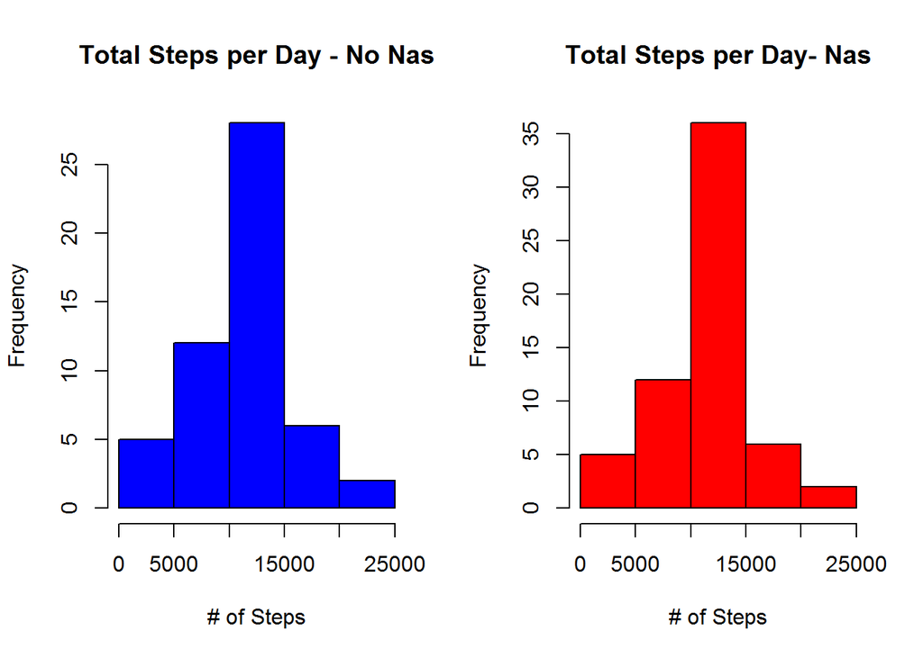

```r
par(mfrow=c(1,2))
hist(pasosdia$steps, main = paste("Total Steps per Day - No Nas"), col="blue", xlab="# of Steps")
hist(pasosnueva$steps, main = paste("Total Steps per Day- Nas"), col="red", xlab="# of Steps")
```

```r
dev.copy(png, file="Gráfica3.png", width= 480, height=480)
```

```r
dev.off()
```

## Are there differences in activity patterns between weekdays and weekends?

1. Create a new factor variable in the dataset with two levels - “weekday” and “weekend” indicating whether a given date is a weekday or weekend day.

We use the data with the missing values corrected for this exercise. We first transform the factor type of “date” variable into class Date. After this we create a new factor variible called “diasemana” with the levels corresponding to the different days of the week (My R Studio is in Spanish so I use the spanish names of the days)

```r
datanueva$date <- as.Date(datanueva$date,format="%Y-%m-%d")
datanueva$diasemana <- factor(format(datanueva$date,"%A"))
levels(datanueva$diasemana) <- list(weekdays = c("lunes", "martes", "miércoles", "jueves","viernes"),weekends = c("sábado", "domingo") )
```

2. Make a panel plot containing a time series plot of the 5-minute interval (x-axis) and the average number of steps taken, averaged across all weekday days or weekend days (y-axis).

Using with () command we aggregate the data by the week variable just created and we plot both functions means

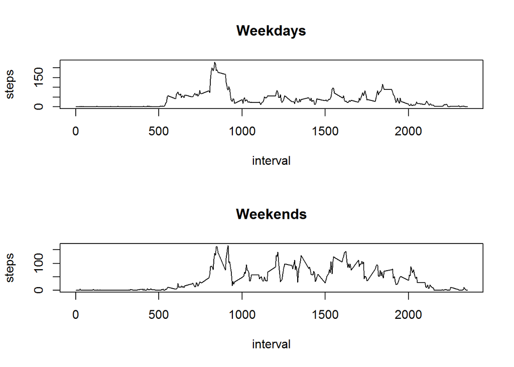

```r
par(mfrow=c(2,1))
with(datanueva[datanueva$diasemana=="weekdays",],plot(aggregate(steps ~ interval, FUN = mean),type="l",main ="Weekdays"))
with(datanueva[datanueva$diasemana=="weekends",],plot(aggregate(steps ~ interval, FUN = mean),type="l",main ="Weekends"))
```

```r
dev.copy(png, file="Gráfica4.png", width= 480, height=480)
```

```r
dev.off()
```

As we observe, activity is much harder during the weekends than in the middle of the week. We finally call the knit2html() function

knit2html(“test.Rmd”)